# lab1

### Анализ матрицы для Китая 2018 г.

```python
import xml.etree.ElementTree as ET
import pandas as pd
import numpy as np
from IPython.display import display
file_name = "china.csv"
df = pd.read_csv(file_name, encoding = "ISO-8859-1")
df = df.dropna(thresh=2, axis = 1)
display(df)
```

|  | To industry / sector | D01T02: Agriculture, hunting, forestry | D03: Fishing and aquaculture | D05T06: Mining and quarrying, energy producing products | D07T08: Mining and quarrying, non-energy producing products | D09: Mining support service activities | D10T12: Food products, beverages and tobacco | D13T15: Textiles, textile products, leather and footwear | D16: Wood and products of wood and cork | D17T18: Paper products and printing | ... | D97T98: Activities of households as employers; undifferentiated goods- and services-producing activities of households for own use | HFCE: Final consumption expenditure of households | NPISH: Final consumption expenditure of non-profit institutions serving households | GGFC: Final consumption expenditure of general government | GFCF: Gross Fixed Capital Formation | INVNT: Changes in inventories | CONS_ABR: Direct purchases abroad by residents (imports) | CONS_NONRES: Direct purchases by non-residents (exports) | EXPO: Exports (cross border) | IMPO: Imports (cross border) |
| --- | --- | --- | --- | --- | --- | --- | --- | --- | --- | --- | --- | --- | --- | --- | --- | --- | --- | --- | --- | --- | --- |
| 0 | TTL_01T02: Agriculture, hunting, forestry | 416 562.10 | 17 333.30 | 701.5 | 141.2 | 0.5 | 600 359.40 | 145 566.50 | 51 524.90 | 34 387.30 | ... | 0 | 380 815.30 | 102.6 | 58 539.10 | 38 134.00 | 17 047.10 | 1 981.10 | 503.9 | 15 225.40 | -73 657.20 |
| 1 | TTL_03: Fishing and aquaculture | 868.7 | 20 075.70 | 0.4 | 2 | 0 | 72 792.70 | 446.6 | 353.7 | 378.2 | ... | 0 | 74 904.40 | 8.4 | 7.1 | 4.8 | -374.9 | 154.1 | 33.7 | 1 227.40 | -3 573.40 |
| 2 | TTL_05T06: Mining and quarrying, energy produc... | 1 864.50 | 103.3 | 86 276.40 | 4 924.30 | 205.6 | 4 328.90 | 4 582.90 | 458.8 | 6 096.20 | ... | 0 | 4 586.80 | 0.1 | 5.4 | 19.9 | -894.6 | 111.3 | 0 | 19 736.30 | -342 714.90 |
| 3 | TTL_07T08: Mining and quarrying, non-energy pr... | 25.4 | 3.2 | 381.3 | 22 896.70 | 144.6 | 108.2 | 45.6 | 12.7 | 1 081.20 | ... | 0 | 1 933.50 | 0 | 2.8 | 11 | 3 264.50 | 54 | 0 | 4 758.00 | -68 484.90 |
| 4 | TTL_09: Mining support service activities | 1.6 | 0.1 | 27 516.10 | 616.7 | 82.6 | 224.2 | 0.9 | 0.5 | 0.5 | ... | 0 | 3.5 | 0 | 1.3 | 4.5 | 14 | 7.1 | 0 | 481.9 | -340.2 |
| 5 | TTL_10T12: Food products, beverages and tobacco | 186 038.50 | 27 572.00 | 1 438.50 | 3 446.10 | 28.8 | 299 928.00 | 17 111.00 | 1 506.70 | 1 936.30 | ... | 0 | 773 594.60 | 314.5 | 31.5 | 154.2 | 14 487.20 | 7 939.60 | 2 124.20 | 55 266.50 | -73 900.60 |
| 6 | TTL_13T15: Textiles, textile products, leather... | 1 032.30 | 51.8 | 6 092.10 | 2 120.80 | 809.9 | 8 491.90 | 739 604.60 | 1 554.50 | 11 884.80 | ... | 0 | 236 890.40 | 114.4 | 6.5 | 70.7 | 14 157.00 | 4 549.90 | 1 517.80 | 275 126.00 | -48 113.10 |
| 7 | TTL_16: Wood and products of wood and cork | 61.6 | 15.7 | 7 627.90 | 864 | 9.7 | 1 125.00 | 1 245.00 | 69 439.40 | 5 734.50 | ... | 0 | 4 797.60 | 2.8 | 2.2 | 61 | 161.9 | 381.4 | 75.8 | 12 184.60 | -12 256.00 |
| 8 | TTL_17T18: Paper products and printing | 562.2 | 160.7 | 119.9 | 848.6 | 40 | 25 290.00 | 5 945.40 | 2 036.80 | 145 107.60 | ... | 0 | 33 312.30 | 30.2 | 10 | 6 841.30 | 5 622.20 | 983.3 | 213.4 | 12 430.60 | -22 505.00 |
| 9 | TTL_19: Coke and refined petroleum products | 12 409.00 | 4 313.30 | 4 989.90 | 25 645.30 | 1 736.90 | 2 004.50 | 2 380.10 | 1 205.90 | 1 221.40 | ... | 0 | 53 113.60 | 55.8 | 41.6 | 90.5 | 8 894.20 | 3 694.40 | 737.2 | 32 088.60 | -52 044.60 |
| 10 | TTL_20: Chemical and chemical products | 169 369.80 | 1 488.90 | 31 655.20 | 21 822.20 | 2 186.80 | 7 432.10 | 81 778.90 | 15 383.80 | 35 259.40 | ... | 0 | 26 737.50 | 48.2 | 134.7 | 291.4 | 10 640.40 | 1 310.60 | 330.9 | 126 780.70 | -140 474.10 |
| 11 | TTL_21: Pharmaceuticals, medicinal chemical an... | 18 133.50 | 2 249.90 | 306.9 | 41.6 | 3.4 | 1 893.80 | 252.7 | 11.3 | 1 378.50 | ... | 0 | 113 698.30 | 88.6 | 32 588.70 | 165.8 | 3 444.60 | 1 043.30 | 261.3 | 26 417.80 | -26 336.00 |
| 12 | TTL_22: Rubber and plastics products | 22 514.80 | 474.5 | 1 784.70 | 3 298.10 | 1 495.20 | 20 533.70 | 17 568.80 | 1 856.80 | 9 204.20 | ... | 0 | 10 663.50 | 0.3 | 16.7 | 317.6 | 4 340.90 | 72 | 0 | 66 694.50 | -21 422.80 |
| 13 | TTL_23: Other non-metallic mineral products | 991.3 | 546.6 | 1 596.90 | 4 606.70 | 1 086.20 | 7 999.50 | 964.9 | 832.4 | 686.3 | ... | 0 | 8 626.50 | 0.2 | 15.3 | 97 | 7 890.40 | 38.7 | 0 | 45 507.10 | -11 993.20 |
| 14 | TTL_24: Basic metals | 688.2 | 213.2 | 20 085.30 | 3 556.20 | 2 467.10 | 680.6 | 851 | 437.4 | 13 002.10 | ... | 0 | 2 011.60 | 0.2 | 14.4 | 464.7 | 5 823.30 | 132.1 | 0 | 83 589.90 | -103 410.20 |
| 15 | TTL_25: Fabricated metal products | 2 070.50 | 234.5 | 12 354.10 | 9 465.80 | 968.3 | 5 009.10 | 3 338.00 | 2 421.00 | 1 493.10 | ... | 0 | 6 772.00 | 5.1 | 10.6 | 137 429.50 | -966 | 86.8 | 0 | 107 479.20 | -31 119.20 |
| 16 | TTL_26: Computer, electronic and optical equip... | 817.8 | 166.2 | 5 817.80 | 446.7 | 571.8 | 1 212.70 | 621.8 | 81.6 | 687.5 | ... | 0 | 96 299.60 | 20.4 | 71.2 | 229 448.30 | 9 767.10 | 1 428.70 | 445.7 | 528 060.00 | -319 241.50 |
| 17 | TTL_27: Electrical equipment | 538.2 | 108.4 | 2 464.50 | 2 952.30 | 181.1 | 907.1 | 716.6 | 157 | 294.4 | ... | 0 | 59 290.40 | 1.7 | 20.3 | 114 571.40 | 4 609.30 | 657.1 | 170.7 | 201 108.00 | -48 499.00 |
| 18 | TTL_28: Machinery and equipment, nec | 19 231.80 | 6 236.20 | 35 438.70 | 19 587.90 | 3 158.20 | 2 815.30 | 4 301.10 | 1 653.20 | 3 031.10 | ... | 0 | 4 444.00 | 8.1 | 49.9 | 531 129.20 | 10 297.70 | 107.1 | 0 | 171 473.40 | -100 933.90 |
| 19 | TTL_29: Motor vehicles, trailers and semi-trai... | 3 345.70 | 894.7 | 598.9 | 3 359.90 | 277.5 | 324.5 | 410.2 | 44.8 | 203.7 | ... | 0 | 149 388.00 | 1.7 | 37.7 | 476 891.00 | 11 873.20 | 837.1 | 195.9 | 45 699.30 | -70 558.50 |
| 20 | TTL_30: Other transport equipment | 1 873.10 | 2 071.10 | 276.8 | 190.5 | 9 | 100.5 | 112.3 | 81.5 | 16.7 | ... | 0 | 19 512.10 | 8.8 | 17.3 | 116 972.20 | 1 475.60 | 37.9 | 0 | 45 373.80 | -42 533.90 |
| 21 | TTL_31T33: Manufacturing nec; repair and insta... | 2 822.00 | 594.6 | 2 663.40 | 956.6 | 235.4 | 2 037.70 | 2 417.70 | 902.2 | 1 189.40 | ... | 0 | 47 164.30 | 16.2 | 78.2 | 56 672.00 | 6 783.10 | 3 905.00 | 1 272.60 | 143 136.50 | -14 444.40 |
| 22 | TTL_35: Electricity, gas, steam and air condit... | 19 996.00 | 1 747.20 | 34 891.30 | 29 167.40 | 820.8 | 10 853.20 | 12 551.50 | 3 717.80 | 8 459.70 | ... | 0 | 103 684.40 | 33.1 | 129 468.00 | 70 | 1 239.90 | 42.1 | 0 | 1 509.60 | -1 108.10 |
| 23 | TTL_36T39: Water supply; sewerage, waste manag... | 3 371.60 | 448.8 | 768.5 | 797.8 | 22.6 | 1 985.80 | 876.4 | 130.6 | 10 931.50 | ... | 0 | 20 919.80 | 466.8 | 13 927.10 | 37 529.50 | -1 002.80 | 20.5 | 0 | 0 | -372.1 |
| 24 | TTL_41T43: Construction | 1 272.80 | 54.4 | 292.1 | 82.5 | 7.2 | 220.8 | 207.4 | 44.8 | 79.2 | ... | 0 | 31 165.90 | 68.9 | 47.4 | 3 236 168.00 | 0 | 124.7 | 0 | 0 | -1 242.40 |
| 25 | TTL_45T47: Wholesale and retail trade; repair ... | 76 088.20 | 8 364.70 | 15 285.10 | 10 896.30 | 1 308.70 | 103 016.90 | 130 323.50 | 10 751.40 | 21 528.50 | ... | 0 | 293 760.30 | 108 | 134 946.10 | 203 327.60 | -1 913.20 | 10 402.50 | 908.5 | 144 365.20 | -194 997.00 |
| 26 | TTL_49: Land transport and transport via pipel... | 41 712.30 | 5 212.40 | 12 477.80 | 7 511.30 | 701.1 | 48 001.10 | 36 666.30 | 6 631.70 | 10 996.70 | ... | 0 | 103 494.50 | 57.3 | 21 637.90 | 52 288.90 | 0 | 19 193.80 | 5 267.50 | 53 928.90 | -70 806.10 |
| 27 | TTL_50: Water transport | 7 087.80 | 1 605.30 | 2 330.10 | 1 416.10 | 84.8 | 4 791.10 | 3 983.20 | 720.2 | 1 647.40 | ... | 0 | 13 024.90 | 1.5 | 4 715.00 | 4 716.80 | 3 462.00 | 4 382.00 | 605.4 | 24 145.80 | -44 090.20 |
| 28 | TTL_51: Air transport | 4 640.50 | 414.3 | 877.8 | 588.2 | 76.1 | 2 703.10 | 4 139.80 | 455.3 | 751.3 | ... | 0 | 18 494.30 | 7.3 | 2 094.70 | 3 927.30 | 692.7 | 11 186.60 | 2 125.10 | 14 068.50 | -46 710.80 |
| 29 | TTL_52: Warehousing and support activities for... | 6 532.40 | 696.2 | 2 425.30 | 1 512.10 | 132.3 | 7 930.40 | 10 132.50 | 1 322.70 | 2 266.40 | ... | 0 | 19 288.00 | 23.5 | 1 230.20 | 14 737.90 | 609.4 | 694.1 | 31.9 | 11 025.10 | -21 053.60 |
| 30 | TTL_53: Postal and courier activities | 5 559.10 | 1 093.10 | 1 194.30 | 351.3 | 34.8 | 4 796.30 | 1 965.30 | 663.4 | 682.4 | ... | 0 | 7 022.20 | 7.6 | 35.8 | 2 156.80 | 387.5 | 380.8 | 48.6 | 4.3 | -588.3 |
| 31 | TTL_55T56: Accommodation and food service acti... | 6 760.80 | 728.5 | 3 395.40 | 2 967.60 | 247.5 | 9 012.20 | 4 114.00 | 846.1 | 2 438.70 | ... | 0 | 302 553.20 | 410.1 | 31.9 | 33.7 | 0 | 79 240.80 | 10 523.40 | 0 | -79 642.70 |
| 32 | TTL_58T60: Publishing, audiovisual and broadca... | 94.7 | 4.4 | 445.2 | 197.7 | 7.2 | 552.9 | 658 | 124.5 | 176.4 | ... | 0 | 38 132.90 | 254.1 | 16 918.20 | 8 853.90 | 214.7 | 1 353.40 | 230.9 | 13 271.80 | -22 726.20 |
| 33 | TTL_61: Telecommunications | 2 645.70 | 344.3 | 442.9 | 478.9 | 20.2 | 894.9 | 708.2 | 164.5 | 366.2 | ... | 0 | 113 202.70 | 60.6 | 41.5 | 216.7 | 133.6 | 5 290.50 | 906.7 | 3 930.70 | -7 508.90 |
| 34 | TTL_62T63: IT and other information services | 1 659.90 | 9.2 | 524.8 | 734.3 | 34 | 1 804.30 | 1 512.20 | 168.8 | 435.7 | ... | 0 | 32 843.10 | 29.8 | 100.3 | 207 772.00 | 1 567.10 | 175.4 | 11.3 | 46 080.90 | -41 751.10 |
| 35 | TTL_64T66: Financial and insurance activities | 25 413.50 | 7 306.80 | 36 317.30 | 10 129.90 | 490 | 7 741.90 | 7 978.60 | 1 777.10 | 6 197.70 | ... | 0 | 291 037.70 | 544.9 | 60 280.70 | 471.4 | 980.2 | 4 404.60 | 777.6 | 8 562.10 | -26 638.80 |
| 36 | TTL_68: Real estate activities | 37 | 1 | 324 | 39.8 | 25.9 | 384.6 | 248 | 65.7 | 99.6 | ... | 0 | 707 149.90 | 612 | 16.1 | 118 773.50 | 67 | 8 437.10 | 2 510.60 | 1 906.90 | -15 075.60 |
| 37 | TTL_69T75: Professional, scientific and techni... | 13 149.40 | 1 161.40 | 11 390.50 | 5 405.20 | 383.9 | 14 653.90 | 6 466.80 | 1 423.20 | 3 987.40 | ... | 0 | 3 302.80 | 500.1 | 83 134.60 | 92 202.00 | 1 352.50 | 2 110.40 | 389.6 | 33 339.10 | -34 695.20 |
| 38 | TTL_77T82: Administrative and support services | 5 413.90 | 1 209.70 | 22 111.90 | 7 897.80 | 468.6 | 25 915.50 | 15 809.30 | 1 804.00 | 4 854.50 | ... | 0 | 78 398.10 | 518.5 | 153 348.70 | 24 071.00 | 686 | 3 521.90 | 783.6 | 14 514.10 | -28 474.80 |
| 39 | TTL_84: Public administration and defence; com... | 769.6 | 86.9 | 196.7 | 166.7 | 7.3 | 343.6 | 321.5 | 78.9 | 110.4 | ... | 0 | 6 501.90 | 723.7 | 857 614.00 | 227.1 | 0 | 574.3 | 0 | 0 | -2 693.30 |
| 40 | TTL_85: Education | 339.9 | 32.6 | 198.5 | 65.2 | 4.2 | 186.4 | 134.4 | 28.9 | 40.5 | ... | 0 | 232 031.90 | 5 726.20 | 371 491.30 | 211.1 | 0 | 38 784.40 | 205.5 | 0 | -39 352.80 |
| 41 | TTL_86T88: Human health and social work activi... | 289.7 | 4.9 | 268.7 | 199.4 | 0.4 | 116.7 | 147.7 | 41.3 | 97 | ... | 0 | 154 360.20 | 7 552.90 | 291 415.90 | 119.7 | 0 | 3 645.00 | 614.8 | 0 | -4 366.40 |
| 42 | TTL_90T93: Arts, entertainment and recreation | 267 | 29.4 | 573.5 | 166.8 | 6.7 | 407.7 | 211.2 | 54.8 | 74.9 | ... | 0 | 60 167.30 | 3 156.30 | 60 955.80 | 54.7 | 16.6 | 8 286.50 | 1 498.10 | 2 610.50 | -18 162.70 |
| 43 | TTL_94T96: Other service activities | 3 294.80 | 434.3 | 856.9 | 236 | 13 | 612.6 | 463.9 | 135.6 | 435.5 | ... | 0 | 205 952.00 | 31 179.00 | 14.8 | 109 | 0 | 4 918.30 | 799.1 | 0 | -5 864.70 |
| 44 | TTL_97T98: Activities of households as employe... | 0 | 0 | 0 | 0 | 0 | 0 | 0 | 0 | 0 | ... | 0 | 0 | 0 | 0 | 0 | 0 | 0 | 0 | 0 | 0 |
| 45 | TXS_IMP_FNL: Taxes less subsidies on intermedi... | 0 | 0 | 0 | 0 | 0 | 0 | 0 | 0 | 0 | ... | 0 | 0 | 0 | 0 | 0 | 0 | 7 791.40 | 0 | 0 | -7 791.40 |
| 46 | TXS_INT_FNL: Taxes less subsidies on intermedi... | -18 998.60 | 832.2 | 7 988.40 | 12 702.20 | 832.6 | 493.2 | 34 442.00 | 3 436.40 | 5 590.50 | ... | 0 | 169 278.00 | 565.6 | 3 712.50 | 231 652.90 | 0 | 0 | -658.5 | 0 | 0 |
| 47 | TTL_INT_FNL: Total intermediate consumption at... | 1 069 220.80 | 116 730.10 | 405 764.20 | 225 500.70 | 21 428.40 | 1 313 018.40 | 1 304 323.90 | 186 545.00 | 356 522.50 | ... | 0 | 5 114 326.00 | 53 435.80 | 2 298 881.00 | 5 949 534.00 | 146 851.60 | 244 473.60 | 35 462.70 | 2 393 109.00 | -2 344 270.00 |
| 48 | VALU: Value added at basic prices | 843 880.10 | 96 076.80 | 216 758.10 | 90 269.20 | 7 304.00 | 410 259.20 | 207 605.20 | 50 768.00 | 119 092.60 | ... | 0 | 0 | 0 | 0 | 0 | 0 | 0 | 0 | 0 | 0 |
| 49 | OUTPUT: Output at basic prices | 1 913 100.80 | 212 807.00 | 622 522.30 | 315 769.90 | 28 732.40 | 1 723 277.60 | 1 511 929.10 | 237 313.00 | 475 615.10 | ... | 0 | 0 | 0 | 0 | 0 | 0 | 0 | 0 | 0 | 0 |

50 rows × 55 columns

### Общий вид межотраслевого баланса представим в виде таблицы:

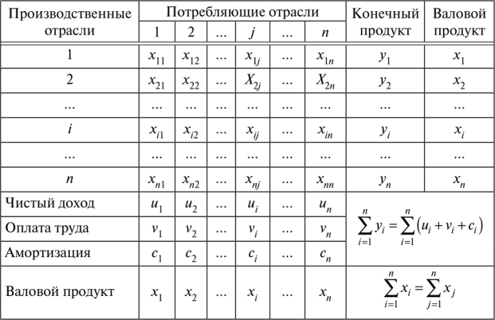

```python
column_dict = {}
print('Столбцы матрицы:')
for i in range(54):
    col = df.columns[i+1]
    column_dict[i] = col
    print(i, col)
    if 'D97T98' not in col:
        df[col] = df[col].str.replace(' ', '').astype(float)
```

```
Столбцы матрицы:
0 D01T02: Agriculture, hunting, forestry
1 D03: Fishing and aquaculture
2 D05T06: Mining and quarrying, energy producing products
3 D07T08: Mining and quarrying, non-energy producing products
4 D09: Mining support service activities
5 D10T12: Food products, beverages and tobacco
6 D13T15: Textiles, textile products, leather and footwear
7 D16: Wood and products of wood and cork
8 D17T18: Paper products and printing
9 D19: Coke and refined petroleum products
10 D20: Chemical and chemical products
11 D21: Pharmaceuticals, medicinal chemical and botanical products
12 D22: Rubber and plastics products
13 D23: Other non-metallic mineral products
```

[output cut: 40 more lines]

```python
display(df.tail(1))
```

|  | To industry / sector | D01T02: Agriculture, hunting, forestry | D03: Fishing and aquaculture | D05T06: Mining and quarrying, energy producing products | D07T08: Mining and quarrying, non-energy producing products | D09: Mining support service activities | D10T12: Food products, beverages and tobacco | D13T15: Textiles, textile products, leather and footwear | D16: Wood and products of wood and cork | D17T18: Paper products and printing | ... | D97T98: Activities of households as employers; undifferentiated goods- and services-producing activities of households for own use | HFCE: Final consumption expenditure of households | NPISH: Final consumption expenditure of non-profit institutions serving households | GGFC: Final consumption expenditure of general government | GFCF: Gross Fixed Capital Formation | INVNT: Changes in inventories | CONS_ABR: Direct purchases abroad by residents (imports) | CONS_NONRES: Direct purchases by non-residents (exports) | EXPO: Exports (cross border) | IMPO: Imports (cross border) |
| --- | --- | --- | --- | --- | --- | --- | --- | --- | --- | --- | --- | --- | --- | --- | --- | --- | --- | --- | --- | --- | --- |
| 49 | OUTPUT: Output at basic prices | 1913100.8 | 212807.0 | 622522.3 | 315769.9 | 28732.4 | 1723277.6 | 1511929.1 | 237313.0 | 475615.1 | ... | 0 | 0.0 | 0.0 | 0.0 | 0.0 | 0.0 | 0.0 | 0.0 | 0.0 | 0.0 |

1 rows × 55 columns

```python
X = np.array(df.tail(1).values.flatten()[1:46]).astype(float)
a = list(df.columns)
Z = df.drop(columns=[x for x in a if x[0] != 'D']).values
Z = np.array(Z[0:45].astype(float))
print(Z.shape, X.shape)
```

```
(45, 45) (45,)
```

Основным элементом модели является квадратная матрица **технологических элементов** (или матрица прямых затрат) размерности nхn: **А = |aij|**. Числа aij показывают сколько продукции отрасли i необходимо затратить для производства единицы продукции отрасли j.

**Xi** - выпуск i-го продукта в единицу времени, например, за год. Эта величина представляет собой валовой выпуск (валовой продукт).

```python
def is_productive(A):
    n = len(A)
    for i in range(1,n):
        if np.linalg.det(np.eye(i) - np.matrix(A, dtype = float)[:i,:i]) < 0:
            print("Матрица D = E - A не продуктивна")
            return 0
    print("Матрица D = E - A продуктивна")
    return 1

A = np.divide(Z, X)
A[np.isnan(A)] = 0
A = np.around(A, decimals = 4)
is_productive(A)
```

```
Матрица D = E - A продуктивна
```

```
1
```

```python
#finding zeros
print(np.where(~A.any(axis=1))[0])
print(np.where((A < 0.04).all(axis=1))[0])
print(np.where((A < 0.05).all(axis=1))[0])
print(np.where((A < 0.06).all(axis=1))[0], len(np.where((A < 0.06).all(axis=1))[0]))
print(np.where((A < 0.1).all(axis=1))[0], len(np.where((A < 0.1).all(axis=1))[0]))
```

```
[44]
[21 24 32 39 40 41 43 44]
[ 4 21 24 29 32 39 40 41 43 44]
[ 4 21 24 26 29 30 31 32 34 37 39 40 41 43 44] 15
[ 1  4 21 24 25 26 27 28 29 30 31 32 34 36 37 38 39 40 41 42 43 44] 22
```

**1. Исключение отраслей**

Нулевая отрасль одна:

- 44-я ***TTL_97T98: Activities of households as employers; undifferentiated goods- and services-producing activities of households for own use.***

При округлении (A < 0.04) 8 нулевых отраслей*:

- 21-я ***D31T33: Manufacturing nec; repair and installation of machinery and equipment***
- 24-я ***D41T43: Construction***
- 32-я ***D58T60: Publishing, audiovisual and broadcasting activities***
- 39-я ***39 D84: Public administration and defence; compulsory social security***
- 40-я ***40 D85: Education***
- 41-я ***TTL_86T88: Human health and social work activities***
- 43-я ***D94T96: Other service activities***
- 44-я

При округлении (A < 0.05) 10 нулевых отраслей:

- 4-я ***D09: Mining support service activities***
- 29-я ***D52: Warehousing and support activities for transportation***
- предыдущие 8 (*)

При округлении (A < 0.06) 15 нулевых отраслей:

При округлении (A < 0.1) 22 нулевые отрасли:

```python
def exclusions(A, exc):
    A1 = A
    exc = np.sort(exc)[::-1]
    n = len(A)
    r = len(exc)
    permute_col = list(range(n))
    poped = [permute_col.pop(x) for x in exc]
    permute_col += poped
    new_A = A[:, permute_col]
    #print(permute_col)

    permute_row = list(range(n))
    poped = [permute_row.pop(x) for x in exc]
    permute_row += poped
    new_A = new_A[permute_row, :]

    nr = n-r
    A11 = new_A[0:nr, 0:nr]
    A22 = new_A[nr:n, nr:n]
    A21 = new_A[0:nr, nr:n]
    A12 = new_A[nr:n, 0:nr]
    #print(r, A22)
    B = np.linalg.inv(np.eye(r)-A22)
    B = np.matmul(B, A12)
    B = np.matmul(A21, B)
    B = A11 - B
    fpA = 1/max(np.linalg.eig(A1)[0])
    fpB = 1/max(np.linalg.eig(B)[0])
    return A1, B, np.real(fpA), np.real(fpB), permute_col
```

```python
exc = np.where((A < 0.05).all(axis=1))[0]
print(exc)
_, B, fpA, fpB, _ = exclusions(np.array(A), exc)
fpA, fpB
```

```
[ 4 21 24 29 32 39 40 41 43 44]
```

```
(1.5528444448631824, 1.6121062088254032)
```

### Агрегирование отраслей

[Источник](https://ilostat.ilo.org/resources/concepts-and-definitions/classification-economic-activities/)

[figure not shown]

```python
agriculture = ['D01T02: Agriculture, hunting, forestry',
 'D03: Fishing and aquaculture']
agriculture_d = {}
# industry
mining_quarring = ['D05T06: Mining and quarrying, energy producing products',
 'D07T08: Mining and quarrying, non-energy producing products',
 'D09: Mining support service activities',
 'D36T39: Water supply; sewerage, waste management and remediation activities']
mining_quarring_d = {}
manufactoring = ['D35: Electricity, gas, steam and air conditioning supply',
                 'D13T15: Textiles, textile products, leather and footwear',
                 'D16: Wood and products of wood and cork',
                 'D17T18: Paper products and printing',
                 'D19: Coke and refined petroleum products',
                 'D20: Chemical and chemical products',
                 'D21: Pharmaceuticals, medicinal chemical and botanical products',
                 'D22: Rubber and plastics products',
                 'D23: Other non-metallic mineral products',
                 'D24: Basic metals',
                 'D25: Fabricated metal products',
                 'D26: Computer, electronic and optical equipment',
                 'D27: Electrical equipment',
                 'D28: Machinery and equipment, nec',
                 'D29: Motor vehicles, trailers and semi-trailers',
                 'D30: Other transport equipment',
                 'D31T33: Manufacturing nec; repair and installation of machinery and equipment']
manufactoring_d = {}
construction = ['D41T43: Construction']
construction_d = {}
#services
market = ['D10T12: Food products, beverages and tobacco',
         'D45T47: Wholesale and retail trade; repair of motor vehicles',
         'D49: Land transport and transport via pipelines',
         'D50: Water transport',
         'D51: Air transport',
         'D52: Warehousing and support activities for transportation',
         'D53: Postal and courier activities',
         'D55T56: Accommodation and food service activities',
         'D58T60: Publishing, audiovisual and broadcasting activities',
         'D61: Telecommunications',
         'D62T63: IT and other information services',
         'D64T66: Financial and insurance activities',
         'D68: Real estate activities',
         'D69T75: Professional, scientific and technical activities',
         'D77T82: Administrative and support services',
         'D84: Public administration and defence; compulsory social security'
         ]
market_d = {}
non_market = ['D85: Education',
 'D86T88: Human health and social work activities',
 'D90T93: Arts, entertainment and recreation',
 'D94T96: Other service activities',
 'D97T98: Activities of households as employers; undifferentiated goods- and services-producing activities of households for own use'
             ]
non_market_d = {}

for key in column_dict:
    if column_dict[key] in agriculture:
        agriculture_d[key] = column_dict[key]

    elif column_dict[key] in non_market:
        non_market_d[key] = column_dict[key]

    elif column_dict[key] in market:
        market_d[key] = column_dict[key]

    elif column_dict[key] in construction:
        construction_d[key] = column_dict[key]

    elif column_dict[key] in manufactoring:
        manufactoring_d[key] = column_dict[key]

    elif column_dict[key] in mining_quarring:
        mining_quarring_d[key] = column_dict[key]


agr_tmp = np.sum(Z[:, list(agriculture_d.keys())], axis = 1)
min_tmp = np.sum(Z[:, list(mining_quarring_d.keys())], axis = 1)
manuf_tmp = np.sum(Z[:, list(manufactoring_d.keys())], axis = 1)
const_tmp = np.sum(Z[:, list(construction_d.keys())], axis = 1)
market_tmp = np.sum(Z[:, list(market_d.keys())], axis = 1)
non_mar_tmp = np.sum(Z[:, list(non_market_d.keys())], axis = 1)

Z_agr = np.array([agr_tmp, min_tmp, manuf_tmp, const_tmp, market_tmp, non_mar_tmp]).T


agr_tmp = np.sum(Z_agr[list(agriculture_d.keys()), :], axis = 0)
min_tmp = np.sum(Z_agr[list(mining_quarring_d.keys()), :],  axis = 0)
manuf_tmp = np.sum(Z_agr[list(manufactoring_d.keys()), :], axis = 0)
const_tmp = np.sum(Z_agr[list(construction_d.keys()), :], axis = 0)
market_tmp = np.sum(Z_agr[list(market_d.keys()), :], axis = 0)
non_mar_tmp = np.sum(Z_agr[list(non_market_d.keys()), :],  axis = 0)

Z_agr = np.array([agr_tmp, min_tmp, manuf_tmp, const_tmp, market_tmp, non_mar_tmp])
np.around(Z_agr, decimals = 4)
```

```
array([[4.5483980e+05, 2.0397000e+03, 3.3110510e+05, 3.0318800e+04,
        7.9085820e+05, 5.6629000e+03],
       [5.8185000e+03, 1.7907450e+05, 1.2275686e+06, 3.9651000e+04,
        2.0829100e+04, 3.0908000e+03],
       [2.9802530e+05, 3.6754160e+05, 7.8684720e+06, 1.6732362e+06,
        1.2883688e+06, 2.1014070e+05],
       [1.3272000e+03, 1.2116000e+03, 4.9651000e+03, 7.9729200e+04,
        1.8142600e+04, 3.1101000e+03],
       [4.3941350e+05, 2.0272280e+05, 2.1533059e+06, 5.7556760e+05,
        2.9074478e+06, 2.0573890e+05],
       [4.6926000e+03, 4.2814000e+03, 1.9563000e+04, 9.9437000e+03,
        6.3370500e+04, 3.7361000e+04]])
```

```python
agr_tmp = np.sum(X[list(agriculture_d.keys())])
min_tmp = np.sum(X[list(mining_quarring_d.keys())])
manuf_tmp = np.sum(X[list(manufactoring_d.keys())])
const_tmp = np.sum(X[list(construction_d.keys())])
market_tmp = np.sum(X[list(market_d.keys())])
non_mar_tmp = np.sum(X[list(non_market_d.keys())])

X_agr = [agr_tmp, min_tmp, manuf_tmp, const_tmp, market_tmp, non_mar_tmp]
X_agr
```

```
[2125907.8,
 1170082.7000000002,
 15505042.100000001,
 3374819.0,
 11282593.7,
 1557342.2]
```

```python
def custom_agregation(Z, X, partition):
    #partition: dict of str-list
    Z_agr = 0
    Z = np.around(Z, decimals = 2)
    X_agr = 0
    for s in partition.keys():
        section = partition[s]
        tmp_vec = np.sum(Z[:, section], axis = 1)
        tmp_x = np.sum(X[section])
        if  isinstance(Z_agr, int):
            Z_agr = tmp_vec
        else:
            Z_agr = np.vstack([Z_agr, tmp_vec])

        if  isinstance(X_agr, int):
            X_agr = tmp_x
        else:
            X_agr = np.vstack([X_agr, tmp_x])
    Z_agr1 = Z_agr.T
    Z_agr = 0
    for s in partition.keys():
        section = partition[s]
        tmp_vec = np.sum(Z_agr1[section, :], axis = 0)
        if  isinstance(Z_agr, int):
            Z_agr = tmp_vec
        else:
            Z_agr = np.vstack([Z_agr, tmp_vec])
    return Z_agr, X_agr

partition = {'Agriculture': list(agriculture_d.keys()),
             'Construction': list(construction_d.keys()),
             'Manufacturing': list(manufactoring_d.keys()),
             'Mining and quarrying': list(mining_quarring_d.keys()),
             'Market Services (Trade; Transportation; Accommodation and food; and Business and administrative services)': list(market_d.keys()),
             'Non-market services (Public administration; Community, Social and other services and activities)': list(non_market_d.keys()),
}
```

```python
Z_agr, X_agr = custom_agregation(Z, X, partition)
A_agr = np.divide(Z_agr, X_agr)
A_agr[np.isnan(A_agr)] = 0
A_agr = np.around(A_agr, decimals = 4)
di_agr = np.sum(A_agr, axis = 0) - np.diag(A_agr)
amax = np.max(A_agr)
di_agr
```

```
array([0.0665, 0.2135, 1.4098, 0.0458, 0.519 , 0.038 ])
```

```python
di = np.sum(A, axis = 0) - np.diag(A)
amax = np.max(A_agr)
di
```

```
array([0.3512, 0.4502, 0.5001, 0.601 , 0.7141, 0.5876, 0.3507, 0.4789,
       0.4328, 0.6951, 0.4305, 0.4374, 0.5837, 0.469 , 0.4361, 0.5713,
       0.3525, 0.6268, 0.5787, 0.4184, 0.6207, 0.641 , 0.4384, 0.4563,
       0.69  , 0.3508, 0.5089, 0.6031, 0.5501, 0.5668, 0.5005, 0.6086,
       0.4761, 0.4414, 0.2896, 0.1193, 0.163 , 0.5179, 0.4547, 0.2837,
       0.2264, 0.3623, 0.2702, 0.2844, 0.    ])
```

```python
import plotly.graph_objects as go
import networkx as nx
import plotly.express as px

def plot_graph(A, di, bottom_ann = 'Китай, 2018 год', right_ann = 'Величина di', title = '<br>Граф связей первого порядка'):
    amax = np.max(A)
    G = nx.Graph()
    for i in range(len(di)):
        if di[i] in G.nodes:
            tmp_val = di[i]+0.001
            while (tmp_val in G.nodes):
                tmp_val += 0.001
            G.add_node(tmp_val)
        else:
            G.add_node(di[i])

    pos=nx.circular_layout(G)

    edge_x = []
    edge_y = []
    edge_color = []

    i = 0
    j = 0
    edge_trace = []
    for edge1 in pos.values():
        for edge2 in pos.values():
            if (edge1 != edge2).any() and (i < len(di)) and (j < len(di)):
                x0, y0 = edge1
                x1, y1 = edge2
                a = max(0, 256 - int(A[i][j]/amax*2000))
                a = str(a)
                edge_color = 'rgb(' + a + ',' + a + ', 100)'
                w = np.abs(A[i][j])/amax
                new_trace = go.Scatter(
                    x=[x0, x1], y=[y0, y1],
                    line=dict(width=w*2, color=edge_color),
                    hoverinfo='none',
                    mode='lines')
                edge_trace.append(new_trace)
            j += 1
        i += 1
        j = 0

    node_x = []
    node_y = []
    for node in pos.values():
        x, y = node
        node_x.append(x)
        node_y.append(y)

    node_trace = go.Scatter(
        x=node_x, y=node_y,
        mode='markers',
        hoverinfo='text',
        marker=dict(
            showscale=True,
            colorscale='YlGnBu',
            reversescale=True,
            color=[],
            size=30,
            colorbar=dict(
                thickness=15,
                title=right_ann,
                xanchor='left',
                titleside='right'
            ),
            line_width=2))


    node_adjacencies = []
    node_text = []
    for node, adjacencies in enumerate(G.adjacency()):
        node_adjacencies.append(adjacencies[0])
        node_text.append('d_i = '+str(adjacencies[0]))

    node_trace.marker.color = node_adjacencies
    node_trace.text = node_text
    edge_trace.append(node_trace)

    i = 1
    x_edge = []
    y_edge = []
    text_edge = []
    for edge in pos.values():
        x_edge.append(edge[0])
        y_edge.append(edge[1])
        text_edge.append(str(i))
        i += 1

    text_trace = go.Scatter(
            x=x_edge,
            y=y_edge,
            mode="text",
            name="Text",
            text=text_edge,
            textposition="bottom center"
        )
    edge_trace.append(text_trace)

    fig = go.Figure(data=edge_trace,
                 layout=go.Layout(
                    title= title,
                    titlefont_size=16,
                    showlegend=False,
                    hovermode='closest',
                    margin=dict(b=20,l=5,r=5,t=40),
                    annotations=[ dict(
                        text=bottom_ann,
                        showarrow=False,
                        x=-1, y=-1 ) ],
                    xaxis=dict(showgrid=False, zeroline=False, showticklabels=False),
                    yaxis=dict(showgrid=False, zeroline=False, showticklabels=False))
                    )
    fig.show()
```

```python
fpA_2018 = 1/max(np.linalg.eig(A)[0])
```

```python
plot_graph(A, di)
```

[interactive chart not shown]

```python
exc = np.where((A < 0.06).all(axis=1))[0]
print('Граф связей матрицы с исключенными отраслями')
print('Исключенные отрасли: ', exc)
_, A1, fpA, fpB, _ = exclusions(np.array(A), exc)
print('Числа ФП: до исключения отраслей', fpA, '\nпосле исключения отраслей       ', fpB)
di = np.sum(A1, axis = 0) - np.diag(A1)
amax = np.max(A1)
plot_graph(A1, di)

labels = [str(x) + ': ' + column_dict[x] for x in range(45) if x not in exc]
fig = px.pie(values=di, names=labels)
fig.show()
```

```
Граф связей матрицы с исключенными отраслями
Исключенные отрасли:  [ 4 21 24 26 29 30 31 32 34 37 39 40 41 43 44]
Числа ФП: до исключения отраслей 1.5528444448631824
после исключения отраслей        1.7497066585702068
```

[interactive chart not shown]

```python
ddi = di*np.sum(A1, axis = 1)
plot_graph(A1, ddi, right_ann = 'Величина ddi', title = '<br>Граф связей второго порядка')
fig = px.pie(values=ddi, names=labels)
fig.show()
```

[interactive chart not shown]

```python
print('Граф связей агрегированной матрицы')
j = 1
for i in partition.keys():
    print(str(j)+'.', i, partition[i])
    j+=1

Z_agr, X_agr = custom_agregation(Z, X, partition)
A_agr = np.divide(Z_agr, X_agr)
A_agr[np.isnan(A_agr)] = 0
A_agr = np.around(A_agr, decimals = 4)
di_agr = np.sum(A_agr, axis = 0) - np.diag(A_agr)
amax = np.max(A_agr)
plot_graph(A_agr, di_agr)

labels = partition.keys()
fig = px.pie(values=di_agr, names=labels, title='Величины связей первого порядка для агрегированной матрицы')
fig.show()

ddi_agr = di_agr*np.sum(A_agr, axis = 1)
fig = px.pie(values=ddi_agr, names=labels, title='Величины связей второго порядка для агрегированной матрицы')
fig.show()
```

```
Граф связей агрегированной матрицы
1. Agriculture [0, 1]
2. Construction [24]
3. Manufacturing [6, 7, 8, 9, 10, 11, 12, 13, 14, 15, 16, 17, 18, 19, 20, 21, 22]
4. Mining and quarrying [2, 3, 4, 23]
5. Market Services (Trade; Transportation; Accommodation and food; and Business and administrative services) [5, 25, 26, 27, 28, 29, 30, 31, 32, 33, 34, 35, 36, 37, 38, 39]
6. Non-market services (Public administration; Community, Social and other services and activities) [40, 41, 42, 43, 44]
```

[interactive chart not shown]

### Анализ матрицы для Китая 2013 г.

```python
file_name = "china2.csv"  # Replace with your file path
df = pd.read_csv(file_name, encoding = "UTF-8")
display(df)
```

|  | To industry / sector | Unnamed: 1 | D01T02: Agriculture, hunting, forestry | D03: Fishing and aquaculture | D05T06: Mining and quarrying, energy producing products | D07T08: Mining and quarrying, non-energy producing products | D09: Mining support service activities | D10T12: Food products, beverages and tobacco | D13T15: Textiles, textile products, leather and footwear | D16: Wood and products of wood and cork | ... | D97T98: Activities of households as employers; undifferentiated goods- and services-producing activities of households for own use | HFCE: Final consumption expenditure of households | NPISH: Final consumption expenditure of non-profit institutions serving households | GGFC: Final consumption expenditure of general government | GFCF: Gross Fixed Capital Formation | INVNT: Changes in inventories | CONS_ABR: Direct purchases abroad by residents (imports) | CONS_NONRES: Direct purchases by non-residents (exports) | EXPO: Exports (cross border) | IMPO: Imports (cross border) |
| --- | --- | --- | --- | --- | --- | --- | --- | --- | --- | --- | --- | --- | --- | --- | --- | --- | --- | --- | --- | --- | --- |
| 0 | From industry / sector | NaN | NaN | NaN | NaN | NaN | NaN | NaN | NaN | NaN | ... | NaN | NaN | NaN | NaN | NaN | NaN | NaN | NaN | NaN | NaN |
| 1 | TTL_01T02: Agriculture, hunting, forestry | NaN | 236,868.600 | 7,606.500 | 343.400 | 162.100 | 31.400 | 495,240.100 | 122,892.600 | 39,818.200 | ... | 0.0 | 282,176.800 | 80.000 | 40,867.600 | 52,971.800 | 82.700 | 971.600 | 605.200 | 12,050.500 | -71,159.500 |
| 2 | TTL_03: Fishing and aquaculture | NaN | 2,214.700 | 25,075.500 | 0.300 | 3.000 | 3.200 | 53,202.500 | 527.600 | 343.600 | ... | 0.0 | 49,235.700 | 5.600 | 9.600 | 9.900 | 5.600 | 77.500 | 41.000 | 1,126.800 | -2,035.700 |
| 3 | TTL_05T06: Mining and quarrying, energy produc... | NaN | 342.900 | 34.700 | 47,754.100 | 2,168.200 | 375.800 | 2,847.600 | 3,051.300 | 572.100 | ... | 0.0 | 4,846.000 | 0.300 | 12.500 | 28.100 | -5.500 | 56.300 | 0.000 | 3,174.500 | -222,152.400 |
| 4 | TTL_07T08: Mining and quarrying, non-energy pr... | NaN | 22.000 | 3.300 | 15,597.800 | 26,309.700 | 39.500 | 365.400 | 19.800 | 41.900 | ... | 0.0 | 1,159.500 | 0.000 | 4.100 | 9.400 | 11.300 | 22.400 | 0.000 | 2,596.900 | -135,559.800 |
| 5 | TTL_09: Mining support service activities | NaN | 3.100 | 0.100 | 20,519.300 | 540.600 | 69.700 | 324.500 | 1.700 | 0.700 | ... | 0.0 | 3.900 | 0.000 | 3.100 | 4.500 | 9.800 | 5.200 | 0.000 | 398.600 | -360.700 |
| 6 | TTL_10T12: Food products, beverages and tobacco | NaN | 172,463.700 | 18,592.000 | 2,695.800 | 2,436.600 | 12.300 | 327,274.400 | 19,659.200 | 1,064.800 | ... | 0.0 | 597,462.400 | 269.100 | 34.400 | 116.100 | 31,473.900 | 3,900.700 | 2,570.000 | 43,980.300 | -49,925.700 |
| 7 | TTL_13T15: Textiles, textile products, leather... | NaN | 960.800 | 13.900 | 1,843.200 | 1,245.600 | 157.800 | 2,755.000 | 497,732.300 | 1,055.900 | ... | 0.0 | 199,914.300 | 76.500 | 8.000 | 51.800 | 11,855.500 | 2,054.600 | 1,834.500 | 269,061.000 | -30,741.100 |
| 8 | TTL_16: Wood and products of wood and cork | NaN | 138.700 | 35.500 | 6,056.400 | 461.600 | 6.200 | 568.100 | 1,175.800 | 65,528.800 | ... | 0.0 | 4,172.300 | 2.300 | 2.500 | 53.000 | 217.400 | 179.900 | 90.400 | 11,750.500 | -7,924.500 |
| 9 | TTL_17T18: Paper products and printing | NaN | 222.400 | 61.700 | 200.500 | 450.200 | 12.500 | 16,191.800 | 4,303.300 | 1,376.000 | ... | 0.0 | 9,907.700 | 21.200 | 17.100 | 4,258.700 | 663.100 | 462.700 | 251.600 | 9,671.900 | -14,246.400 |
| 10 | TTL_19: Coke and refined petroleum products | NaN | 16,659.400 | 4,647.400 | 12,580.000 | 10,803.600 | 863.300 | 1,506.000 | 1,246.200 | 747.000 | ... | 0.0 | 31,861.300 | 38.800 | 16.700 | 62.600 | 2,319.700 | 1,799.100 | 894.900 | 15,180.100 | -43,731.600 |
| 11 | TTL_20: Chemical and chemical products | NaN | 122,916.100 | 822.400 | 10,658.500 | 13,141.900 | 1,425.300 | 8,106.500 | 60,073.000 | 12,191.700 | ... | 0.0 | 25,478.000 | 41.800 | 70.500 | 214.500 | 1,519.200 | 659.900 | 395.000 | 87,655.100 | -116,838.700 |
| 12 | TTL_21: Pharmaceuticals, medicinal chemical an... | NaN | 13,602.900 | 1,012.200 | 91.500 | 65.500 | 12.300 | 980.100 | 195.800 | 6.900 | ... | 0.0 | 73,810.700 | 64.600 | 23,562.800 | 73.200 | 3,432.300 | 465.500 | 311.800 | 16,644.200 | -11,893.700 |
| 13 | TTL_22: Rubber and plastics products | NaN | 10,818.300 | 182.100 | 1,394.400 | 2,687.700 | 715.200 | 15,827.100 | 12,731.300 | 2,009.800 | ... | 0.0 | 6,569.600 | 0.200 | 17.900 | 202.600 | 775.300 | 30.600 | 0.000 | 56,871.500 | -22,442.000 |
| 14 | TTL_23: Other non-metallic mineral products | NaN | 373.800 | 146.600 | 1,307.300 | 2,757.000 | 836.400 | 5,503.300 | 639.600 | 387.100 | ... | 0.0 | 8,865.800 | 0.100 | 13.600 | 72.100 | 770.600 | 15.600 | 0.000 | 45,095.600 | -9,907.800 |
| 15 | TTL_24: Basic metals | NaN | 91.700 | 9.000 | 15,058.300 | 2,684.800 | 1,062.000 | 203.900 | 364.100 | 247.000 | ... | 0.0 | 1,071.300 | 0.200 | 17.500 | 334.600 | 852.800 | 76.700 | 0.000 | 68,636.900 | -109,344.100 |
| 16 | TTL_25: Fabricated metal products | NaN | 766.600 | 62.800 | 7,067.100 | 6,858.800 | 655.300 | 3,626.000 | 1,077.600 | 4,177.600 | ... | 0.0 | 7,663.500 | 4.600 | 17.400 | 44,689.100 | 2,765.300 | 50.100 | 0.000 | 73,349.100 | -13,282.400 |
| 17 | TTL_26: Computer, electronic and optical equip... | NaN | 296.300 | 38.300 | 4,047.100 | 624.500 | 280.900 | 312.100 | 316.200 | 167.800 | ... | 0.0 | 69,261.300 | 16.700 | 149.700 | 96,959.300 | 7,721.500 | 715.400 | 589.500 | 438,956.600 | -260,576.400 |
| 18 | TTL_27: Electrical equipment | NaN | 257.000 | 33.800 | 2,225.700 | 2,229.100 | 119.900 | 547.100 | 513.400 | 175.400 | ... | 0.0 | 60,902.000 | 1.400 | 35.400 | 116,900.900 | 8,287.800 | 315.900 | 203.700 | 170,350.400 | -38,021.900 |
| 19 | TTL_28: Machinery and equipment, nec | NaN | 9,183.400 | 2,100.900 | 20,938.800 | 16,602.900 | 1,885.900 | 3,491.300 | 5,575.000 | 2,325.200 | ... | 0.0 | 3,180.000 | 6.200 | 58.300 | 468,221.200 | 23,385.300 | 42.600 | 0.000 | 134,708.200 | -100,528.700 |
| 20 | TTL_29: Motor vehicles, trailers and semi-trai... | NaN | 1,457.100 | 247.700 | 588.600 | 2,407.300 | 153.600 | 213.700 | 114.700 | 26.600 | ... | 0.0 | 125,251.300 | 1.700 | 63.600 | 331,119.100 | 25,184.700 | 410.700 | 237.400 | 39,215.800 | -67,554.100 |
| 21 | TTL_30: Other transport equipment | NaN | 162.000 | 368.200 | 57.600 | 58.800 | 3.100 | 14.900 | 14.500 | 5.800 | ... | 0.0 | 18,092.500 | 6.800 | 31.300 | 74,972.800 | 5,034.800 | 17.100 | 0.000 | 53,580.700 | -35,941.000 |
| 22 | TTL_31T33: Manufacturing nec; repair and insta... | NaN | 554.700 | 59.500 | 929.100 | 701.800 | 105.500 | 801.900 | 1,413.200 | 389.400 | ... | 0.0 | 19,537.200 | 5.200 | 34.200 | 10,813.200 | 2,107.700 | 1,743.000 | 1,436.900 | 142,189.900 | -14,534.400 |
| 23 | TTL_35: Electricity, gas, steam and air condit... | NaN | 12,424.900 | 881.100 | 20,263.200 | 18,848.700 | 593.800 | 8,211.100 | 10,415.100 | 2,987.400 | ... | 0.0 | 64,846.000 | 26.500 | 102,158.600 | 79.400 | 30.500 | 18.500 | 0.000 | 1,376.400 | -2,290.500 |
| 24 | TTL_36T39: Water supply; sewerage, waste manag... | NaN | 1,735.600 | 175.900 | 391.700 | 716.800 | 26.800 | 1,128.800 | 835.000 | 116.100 | ... | 0.0 | 12,086.900 | 422.700 | 11,426.700 | 22,020.800 | 0.100 | 7.800 | 0.000 | 0.000 | -278.300 |
| 25 | TTL_41T43: Construction | NaN | 168.000 | 5.800 | 1,191.300 | 789.700 | 45.500 | 1,486.600 | 911.200 | 247.200 | ... | 0.0 | 31,949.600 | 85.300 | 59.100 | 2,321,478.000 | 0.200 | 62.500 | 0.000 | 0.000 | -1,001.800 |
| 26 | TTL_45T47: Wholesale and retail trade; repair ... | NaN | 49,854.100 | 5,610.800 | 8,743.900 | 6,599.500 | 642.900 | 86,707.300 | 86,653.900 | 8,725.700 | ... | 0.0 | 196,805.500 | 79.800 | 52,682.500 | 114,420.100 | -2,698.700 | 4,860.900 | 1,060.700 | 131,269.500 | -151,837.400 |
| 27 | TTL_49: Land transport and transport via pipel... | NaN | 21,176.300 | 2,678.500 | 8,871.100 | 6,677.700 | 347.400 | 38,941.900 | 23,133.500 | 5,750.200 | ... | 0.0 | 64,570.200 | 37.900 | 20,769.900 | 31,483.900 | 11.000 | 9,319.200 | 6,115.000 | 41,895.400 | -54,552.600 |
| 28 | TTL_50: Water transport | NaN | 1,861.900 | 244.700 | 833.400 | 749.500 | 22.100 | 2,780.900 | 1,865.600 | 403.400 | ... | 0.0 | 4,828.900 | 1.700 | 1,389.900 | 2,782.900 | 5,719.000 | 2,089.600 | 685.300 | 29,171.000 | -38,149.300 |
| 29 | TTL_51: Air transport | NaN | 1,379.200 | 135.100 | 509.900 | 376.600 | 23.600 | 2,057.600 | 1,551.300 | 323.800 | ... | 0.0 | 6,408.600 | 4.200 | 1,521.300 | 1,548.000 | 805.000 | 5,486.600 | 2,534.400 | 15,971.600 | -32,815.900 |
| 30 | TTL_52: Warehousing and support activities for... | NaN | 4,502.000 | 549.800 | 1,662.800 | 1,164.200 | 59.800 | 7,623.100 | 5,023.000 | 1,126.200 | ... | 0.0 | 10,875.000 | 12.800 | 781.100 | 6,329.800 | 182.600 | 306.900 | 48.900 | 12,565.700 | -18,513.200 |
| 31 | TTL_53: Postal and courier activities | NaN | 1,465.100 | 196.700 | 625.700 | 260.300 | 7.300 | 1,288.300 | 430.200 | 163.800 | ... | 0.0 | 7,143.200 | 9.300 | 30.200 | 779.000 | 0.300 | 177.800 | 58.300 | 5.200 | -329.200 |
| 32 | TTL_55T56: Accommodation and food service acti... | NaN | 1,558.800 | 108.500 | 1,599.700 | 1,904.600 | 84.300 | 4,952.800 | 2,208.000 | 645.800 | ... | 0.0 | 168,221.800 | 306.500 | 24.400 | 22.300 | 0.100 | 36,335.200 | 9,353.000 | 0.000 | -36,585.100 |
| 33 | TTL_58T60: Publishing, audiovisual and broadca... | NaN | 28.500 | 1.200 | 232.600 | 246.300 | 6.700 | 458.300 | 469.600 | 104.000 | ... | 0.0 | 19,898.800 | 237.300 | 15,435.700 | 5,142.000 | 212.900 | 628.100 | 275.600 | 11,569.000 | -13,943.500 |
| 34 | TTL_61: Telecommunications | NaN | 1,196.400 | 120.000 | 329.500 | 469.000 | 13.800 | 801.200 | 641.400 | 164.700 | ... | 0.0 | 76,324.700 | 36.100 | 42.300 | 128.100 | 140.400 | 2,519.200 | 1,087.800 | 5,572.300 | -3,558.700 |
| 35 | TTL_62T63: IT and other information services | NaN | 263.200 | 1.200 | 367.200 | 671.900 | 74.400 | 611.900 | 1,174.100 | 212.500 | ... | 0.0 | 9,151.900 | 62.200 | 81.500 | 227,314.800 | 464.600 | 77.200 | 13.600 | 19,688.900 | -16,386.000 |
| 36 | TTL_64T66: Financial and insurance activities | NaN | 13,922.400 | 2,567.400 | 14,256.400 | 7,304.300 | 378.200 | 10,858.000 | 7,577.100 | 2,428.200 | ... | 0.0 | 171,943.100 | 475.200 | 15,933.100 | 287.000 | 650.900 | 2,164.800 | 933.700 | 6,867.900 | -36,472.200 |
| 37 | TTL_68: Real estate activities | NaN | 24.000 | 0.300 | 117.100 | 53.100 | 9.600 | 290.700 | 407.000 | 83.500 | ... | 0.0 | 416,891.600 | 556.000 | 14.600 | 127,544.900 | 75.200 | 4,099.900 | 3,010.800 | 2,436.300 | -7,612.200 |
| 38 | TTL_69T75: Professional, scientific and techni... | NaN | 5,230.600 | 221.400 | 6,427.500 | 4,325.100 | 216.400 | 8,382.200 | 3,362.200 | 1,092.900 | ... | 0.0 | 2,537.600 | 440.200 | 104,906.800 | 19,389.200 | 939.400 | 1,027.300 | 466.300 | 28,854.400 | -24,848.800 |
| 39 | TTL_77T82: Administrative and support services | NaN | 763.500 | 89.300 | 7,387.000 | 5,030.600 | 129.800 | 10,833.300 | 6,157.500 | 1,180.100 | ... | 0.0 | 25,360.800 | 337.300 | 25,932.700 | 12,144.900 | 412.800 | 1,629.200 | 949.200 | 14,132.400 | -18,186.700 |
| 40 | TTL_84: Public administration and defence; com... | NaN | 504.600 | 39.700 | 151.600 | 180.500 | 5.600 | 383.400 | 173.900 | 120.100 | ... | 0.0 | 3,333.400 | 503.600 | 538,202.100 | 157.900 | 0.800 | 298.400 | 0.000 | 0.000 | -2,395.600 |
| 41 | TTL_85: Education | NaN | 155.200 | 10.700 | 210.300 | 95.900 | 2.700 | 179.300 | 103.000 | 24.300 | ... | 0.0 | 69,076.600 | 3,636.400 | 294,798.900 | 69.700 | 0.100 | 22,498.800 | 689.800 | 0.000 | -22,951.600 |
| 42 | TTL_86T88: Human health and social work activi... | NaN | 115.100 | 2.000 | 113.200 | 96.100 | 0.400 | 65.500 | 97.000 | 28.700 | ... | 0.0 | 111,845.600 | 5,735.200 | 191,468.300 | 78.200 | 0.000 | 1,783.400 | 737.500 | 0.000 | -2,445.800 |
| 43 | TTL_90T93: Arts, entertainment and recreation | NaN | 33.600 | 2.400 | 136.000 | 131.000 | 3.100 | 274.700 | 147.000 | 38.300 | ... | 0.0 | 13,132.800 | 1,849.000 | 76,865.000 | 33.800 | 16.700 | 4,089.200 | 1,794.900 | 2,825.400 | -9,004.900 |
| 44 | TTL_94T96: Other service activities | NaN | 990.700 | 106.200 | 1,132.700 | 386.400 | 14.700 | 1,124.200 | 724.100 | 137.600 | ... | 0.0 | 90,089.900 | 18,394.900 | 409.600 | 4,298.100 | -6.200 | 2,287.700 | 966.200 | 989.200 | -2,558.200 |
| 45 | TTL_97T98: Activities of households as employe... | NaN | 0.000 | 0.000 | 0.000 | 0.000 | 0.000 | 0.000 | 0.000 | 0.000 | ... | 0.0 | 0.000 | 0.000 | 0.000 | 0.000 | 0.000 | 0.000 | 0.000 | 0.000 | 0.000 |
| 46 | TXS_IMP_FNL: Taxes less subsidies on intermedi... | NaN | -2.000 | 0.000 | -0.100 | 0.000 | 0.000 | -0.200 | 0.000 | -5.000 | ... | 0.0 | 0.000 | 0.000 | 0.000 | 0.000 | 0.000 | 4,282.500 | 0.000 | 0.000 | -4,269.700 |
| 47 | TXS_INT_FNL: Taxes less subsidies on intermedi... | NaN | -5,931.500 | 1,496.100 | 8,751.700 | 6,568.900 | 435.100 | 6,516.100 | 25,161.000 | 2,492.200 | ... | 0.0 | 136,765.700 | 352.300 | 1,915.800 | 160,324.500 | 0.000 | 0.000 | -789.700 | 0.000 | 0.000 |
| 48 | TTL_INT_FNL: Total intermediate consumption at... | NaN | 703,796.300 | 76,398.500 | 256,260.000 | 159,048.300 | 11,971.300 | 1,135,860.300 | 912,859.800 | 161,250.900 | ... | 0.0 | 3,314,511.000 | 34,245.600 | 1,521,898.000 | 4,259,996.000 | 135,428.400 | 120,123.700 | 39,453.200 | 2,021,435.000 | -1,879,690.000 |
| 49 | VALU: Value added at basic prices | NaN | 722,635.300 | 82,273.000 | 236,484.700 | 128,571.600 | 9,750.300 | 359,281.000 | 246,245.700 | 45,755.000 | ... | 0.0 | 0.000 | 0.000 | 0.000 | 0.000 | 0.000 | 0.000 | 0.000 | 0.000 | 0.000 |
| 50 | OUTPUT: Output at basic prices | NaN | 1,426,431.600 | 158,671.500 | 492,744.800 | 287,619.900 | 21,721.600 | 1,495,141.300 | 1,159,105.500 | 207,005.900 | ... | 0.0 | 0.000 | 0.000 | 0.000 | 0.000 | 0.000 | 0.000 | 0.000 | 0.000 | 0.000 |
| 51 | Data extracted on 02 Oct 2023 08:48 UTC (GMT) ... | NaN | NaN | NaN | NaN | NaN | NaN | NaN | NaN | NaN | ... | NaN | NaN | NaN | NaN | NaN | NaN | NaN | NaN | NaN | NaN |

52 rows × 56 columns

```python
for i in range(53):
    col = df.columns[i+2]
    if 'D97T98' not in col:
        df[col] = df[col].str.replace(' ', '')
        df[col] = df[col].str.replace(',', '').astype(float)
df = df.dropna(thresh=2, axis = 1)
df = df.drop(index = [0,51])
display(df)
X = np.array(df.tail(1).values.flatten()[1:46]).astype(float)
Z = df.drop(df.columns[[0, 46,47,48,49,50,51,52,53,54]], axis = 1).values
Z = np.array(Z[0:45].astype(float))
A = np.divide(Z, X)
print(Z)
print(X)
A[np.isnan(A)] = 0
A = np.around(A, decimals = 4)
#finding zeros
np.where(~A.any(axis=1))[0]
```

|  | To industry / sector | D01T02: Agriculture, hunting, forestry | D03: Fishing and aquaculture | D05T06: Mining and quarrying, energy producing products | D07T08: Mining and quarrying, non-energy producing products | D09: Mining support service activities | D10T12: Food products, beverages and tobacco | D13T15: Textiles, textile products, leather and footwear | D16: Wood and products of wood and cork | D17T18: Paper products and printing | ... | D97T98: Activities of households as employers; undifferentiated goods- and services-producing activities of households for own use | HFCE: Final consumption expenditure of households | NPISH: Final consumption expenditure of non-profit institutions serving households | GGFC: Final consumption expenditure of general government | GFCF: Gross Fixed Capital Formation | INVNT: Changes in inventories | CONS_ABR: Direct purchases abroad by residents (imports) | CONS_NONRES: Direct purchases by non-residents (exports) | EXPO: Exports (cross border) | IMPO: Imports (cross border) |
| --- | --- | --- | --- | --- | --- | --- | --- | --- | --- | --- | --- | --- | --- | --- | --- | --- | --- | --- | --- | --- | --- |
| 1 | TTL_01T02: Agriculture, hunting, forestry | 236868.6 | 7606.5 | 343.4 | 162.1 | 31.4 | 495240.1 | 122892.6 | 39818.2 | 22728.8 | ... | 0.0 | 282176.8 | 80.0 | 40867.6 | 52971.8 | 82.7 | 971.6 | 605.2 | 12050.5 | -71,159.500 |
| 2 | TTL_03: Fishing and aquaculture | 2214.7 | 25075.5 | 0.3 | 3.0 | 3.2 | 53202.5 | 527.6 | 343.6 | 295.7 | ... | 0.0 | 49235.7 | 5.6 | 9.6 | 9.9 | 5.6 | 77.5 | 41.0 | 1126.8 | -2,035.700 |
| 3 | TTL_05T06: Mining and quarrying, energy produc... | 342.9 | 34.7 | 47754.1 | 2168.2 | 375.8 | 2847.6 | 3051.3 | 572.1 | 4150.2 | ... | 0.0 | 4846.0 | 0.3 | 12.5 | 28.1 | -5.5 | 56.3 | 0.0 | 3174.5 | -222,152.400 |
| 4 | TTL_07T08: Mining and quarrying, non-energy pr... | 22.0 | 3.3 | 15597.8 | 26309.7 | 39.5 | 365.4 | 19.8 | 41.9 | 196.4 | ... | 0.0 | 1159.5 | 0.0 | 4.1 | 9.4 | 11.3 | 22.4 | 0.0 | 2596.9 | -135,559.800 |
| 5 | TTL_09: Mining support service activities | 3.1 | 0.1 | 20519.3 | 540.6 | 69.7 | 324.5 | 1.7 | 0.7 | 1.0 | ... | 0.0 | 3.9 | 0.0 | 3.1 | 4.5 | 9.8 | 5.2 | 0.0 | 398.6 | -360.700 |
| 6 | TTL_10T12: Food products, beverages and tobacco | 172463.7 | 18592.0 | 2695.8 | 2436.6 | 12.3 | 327274.4 | 19659.2 | 1064.8 | 2502.8 | ... | 0.0 | 597462.4 | 269.1 | 34.4 | 116.1 | 31473.9 | 3900.7 | 2570.0 | 43980.3 | -49,925.700 |
| 7 | TTL_13T15: Textiles, textile products, leather... | 960.8 | 13.9 | 1843.2 | 1245.6 | 157.8 | 2755.0 | 497732.3 | 1055.9 | 4935.3 | ... | 0.0 | 199914.3 | 76.5 | 8.0 | 51.8 | 11855.5 | 2054.6 | 1834.5 | 269061.0 | -30,741.100 |
| 8 | TTL_16: Wood and products of wood and cork | 138.7 | 35.5 | 6056.4 | 461.6 | 6.2 | 568.1 | 1175.8 | 65528.8 | 4313.9 | ... | 0.0 | 4172.3 | 2.3 | 2.5 | 53.0 | 217.4 | 179.9 | 90.4 | 11750.5 | -7,924.500 |
| 9 | TTL_17T18: Paper products and printing | 222.4 | 61.7 | 200.5 | 450.2 | 12.5 | 16191.8 | 4303.3 | 1376.0 | 110521.9 | ... | 0.0 | 9907.7 | 21.2 | 17.1 | 4258.7 | 663.1 | 462.7 | 251.6 | 9671.9 | -14,246.400 |
| 10 | TTL_19: Coke and refined petroleum products | 16659.4 | 4647.4 | 12580.0 | 10803.6 | 863.3 | 1506.0 | 1246.2 | 747.0 | 874.4 | ... | 0.0 | 31861.3 | 38.8 | 16.7 | 62.6 | 2319.7 | 1799.1 | 894.9 | 15180.1 | -43,731.600 |
| 11 | TTL_20: Chemical and chemical products | 122916.1 | 822.4 | 10658.5 | 13141.9 | 1425.3 | 8106.5 | 60073.0 | 12191.7 | 32655.9 | ... | 0.0 | 25478.0 | 41.8 | 70.5 | 214.5 | 1519.2 | 659.9 | 395.0 | 87655.1 | -116,838.700 |
| 12 | TTL_21: Pharmaceuticals, medicinal chemical an... | 13602.9 | 1012.2 | 91.5 | 65.5 | 12.3 | 980.1 | 195.8 | 6.9 | 339.4 | ... | 0.0 | 73810.7 | 64.6 | 23562.8 | 73.2 | 3432.3 | 465.5 | 311.8 | 16644.2 | -11,893.700 |
| 13 | TTL_22: Rubber and plastics products | 10818.3 | 182.1 | 1394.4 | 2687.7 | 715.2 | 15827.1 | 12731.3 | 2009.8 | 10084.3 | ... | 0.0 | 6569.6 | 0.2 | 17.9 | 202.6 | 775.3 | 30.6 | 0.0 | 56871.5 | -22,442.000 |
| 14 | TTL_23: Other non-metallic mineral products | 373.8 | 146.6 | 1307.3 | 2757.0 | 836.4 | 5503.3 | 639.6 | 387.1 | 414.3 | ... | 0.0 | 8865.8 | 0.1 | 13.6 | 72.1 | 770.6 | 15.6 | 0.0 | 45095.6 | -9,907.800 |
| 15 | TTL_24: Basic metals | 91.7 | 9.0 | 15058.3 | 2684.8 | 1062.0 | 203.9 | 364.1 | 247.0 | 4072.0 | ... | 0.0 | 1071.3 | 0.2 | 17.5 | 334.6 | 852.8 | 76.7 | 0.0 | 68636.9 | -109,344.100 |
| 16 | TTL_25: Fabricated metal products | 766.6 | 62.8 | 7067.1 | 6858.8 | 655.3 | 3626.0 | 1077.6 | 4177.6 | 1571.8 | ... | 0.0 | 7663.5 | 4.6 | 17.4 | 44689.1 | 2765.3 | 50.1 | 0.0 | 73349.1 | -13,282.400 |
| 17 | TTL_26: Computer, electronic and optical equip... | 296.3 | 38.3 | 4047.1 | 624.5 | 280.9 | 312.1 | 316.2 | 167.8 | 494.6 | ... | 0.0 | 69261.3 | 16.7 | 149.7 | 96959.3 | 7721.5 | 715.4 | 589.5 | 438956.6 | -260,576.400 |
| 18 | TTL_27: Electrical equipment | 257.0 | 33.8 | 2225.7 | 2229.1 | 119.9 | 547.1 | 513.4 | 175.4 | 349.0 | ... | 0.0 | 60902.0 | 1.4 | 35.4 | 116900.9 | 8287.8 | 315.9 | 203.7 | 170350.4 | -38,021.900 |
| 19 | TTL_28: Machinery and equipment, nec | 9183.4 | 2100.9 | 20938.8 | 16602.9 | 1885.9 | 3491.3 | 5575.0 | 2325.2 | 3670.7 | ... | 0.0 | 3180.0 | 6.2 | 58.3 | 468221.2 | 23385.3 | 42.6 | 0.0 | 134708.2 | -100,528.700 |
| 20 | TTL_29: Motor vehicles, trailers and semi-trai... | 1457.1 | 247.7 | 588.6 | 2407.3 | 153.6 | 213.7 | 114.7 | 26.6 | 103.4 | ... | 0.0 | 125251.3 | 1.7 | 63.6 | 331119.1 | 25184.7 | 410.7 | 237.4 | 39215.8 | -67,554.100 |
| 21 | TTL_30: Other transport equipment | 162.0 | 368.2 | 57.6 | 58.8 | 3.1 | 14.9 | 14.5 | 5.8 | 8.6 | ... | 0.0 | 18092.5 | 6.8 | 31.3 | 74972.8 | 5034.8 | 17.1 | 0.0 | 53580.7 | -35,941.000 |
| 22 | TTL_31T33: Manufacturing nec; repair and insta... | 554.7 | 59.5 | 929.1 | 701.8 | 105.5 | 801.9 | 1413.2 | 389.4 | 655.8 | ... | 0.0 | 19537.2 | 5.2 | 34.2 | 10813.2 | 2107.7 | 1743.0 | 1436.9 | 142189.9 | -14,534.400 |
| 23 | TTL_35: Electricity, gas, steam and air condit... | 12424.9 | 881.1 | 20263.2 | 18848.7 | 593.8 | 8211.1 | 10415.1 | 2987.4 | 6370.8 | ... | 0.0 | 64846.0 | 26.5 | 102158.6 | 79.4 | 30.5 | 18.5 | 0.0 | 1376.4 | -2,290.500 |
| 24 | TTL_36T39: Water supply; sewerage, waste manag... | 1735.6 | 175.9 | 391.7 | 716.8 | 26.8 | 1128.8 | 835.0 | 116.1 | 7368.4 | ... | 0.0 | 12086.9 | 422.7 | 11426.7 | 22020.8 | 0.1 | 7.8 | 0.0 | 0.0 | -278.300 |
| 25 | TTL_41T43: Construction | 168.0 | 5.8 | 1191.3 | 789.7 | 45.5 | 1486.6 | 911.2 | 247.2 | 627.0 | ... | 0.0 | 31949.6 | 85.3 | 59.1 | 2321478.0 | 0.2 | 62.5 | 0.0 | 0.0 | -1,001.800 |
| 26 | TTL_45T47: Wholesale and retail trade; repair ... | 49854.1 | 5610.8 | 8743.9 | 6599.5 | 642.9 | 86707.3 | 86653.9 | 8725.7 | 15269.9 | ... | 0.0 | 196805.5 | 79.8 | 52682.5 | 114420.1 | -2698.7 | 4860.9 | 1060.7 | 131269.5 | -151,837.400 |
| 27 | TTL_49: Land transport and transport via pipel... | 21176.3 | 2678.5 | 8871.1 | 6677.7 | 347.4 | 38941.9 | 23133.5 | 5750.2 | 9010.0 | ... | 0.0 | 64570.2 | 37.9 | 20769.9 | 31483.9 | 11.0 | 9319.2 | 6115.0 | 41895.4 | -54,552.600 |
| 28 | TTL_50: Water transport | 1861.9 | 244.7 | 833.4 | 749.5 | 22.1 | 2780.9 | 1865.6 | 403.4 | 689.5 | ... | 0.0 | 4828.9 | 1.7 | 1389.9 | 2782.9 | 5719.0 | 2089.6 | 685.3 | 29171.0 | -38,149.300 |
| 29 | TTL_51: Air transport | 1379.2 | 135.1 | 509.9 | 376.6 | 23.6 | 2057.6 | 1551.3 | 323.8 | 585.6 | ... | 0.0 | 6408.6 | 4.2 | 1521.3 | 1548.0 | 805.0 | 5486.6 | 2534.4 | 15971.6 | -32,815.900 |
| 30 | TTL_52: Warehousing and support activities for... | 4502.0 | 549.8 | 1662.8 | 1164.2 | 59.8 | 7623.1 | 5023.0 | 1126.2 | 1742.8 | ... | 0.0 | 10875.0 | 12.8 | 781.1 | 6329.8 | 182.6 | 306.9 | 48.9 | 12565.7 | -18,513.200 |
| 31 | TTL_53: Postal and courier activities | 1465.1 | 196.7 | 625.7 | 260.3 | 7.3 | 1288.3 | 430.2 | 163.8 | 416.3 | ... | 0.0 | 7143.2 | 9.3 | 30.2 | 779.0 | 0.3 | 177.8 | 58.3 | 5.2 | -329.200 |
| 32 | TTL_55T56: Accommodation and food service acti... | 1558.8 | 108.5 | 1599.7 | 1904.6 | 84.3 | 4952.8 | 2208.0 | 645.8 | 1670.7 | ... | 0.0 | 168221.8 | 306.5 | 24.4 | 22.3 | 0.1 | 36335.2 | 9353.0 | 0.0 | -36,585.100 |
| 33 | TTL_58T60: Publishing, audiovisual and broadca... | 28.5 | 1.2 | 232.6 | 246.3 | 6.7 | 458.3 | 469.6 | 104.0 | 221.7 | ... | 0.0 | 19898.8 | 237.3 | 15435.7 | 5142.0 | 212.9 | 628.1 | 275.6 | 11569.0 | -13,943.500 |
| 34 | TTL_61: Telecommunications | 1196.4 | 120.0 | 329.5 | 469.0 | 13.8 | 801.2 | 641.4 | 164.7 | 375.9 | ... | 0.0 | 76324.7 | 36.1 | 42.3 | 128.1 | 140.4 | 2519.2 | 1087.8 | 5572.3 | -3,558.700 |
| 35 | TTL_62T63: IT and other information services | 263.2 | 1.2 | 367.2 | 671.9 | 74.4 | 611.9 | 1174.1 | 212.5 | 404.6 | ... | 0.0 | 9151.9 | 62.2 | 81.5 | 227314.8 | 464.6 | 77.2 | 13.6 | 19688.9 | -16,386.000 |
| 36 | TTL_64T66: Financial and insurance activities | 13922.4 | 2567.4 | 14256.4 | 7304.3 | 378.2 | 10858.0 | 7577.1 | 2428.2 | 6630.1 | ... | 0.0 | 171943.1 | 475.2 | 15933.1 | 287.0 | 650.9 | 2164.8 | 933.7 | 6867.9 | -36,472.200 |
| 37 | TTL_68: Real estate activities | 24.0 | 0.3 | 117.1 | 53.1 | 9.6 | 290.7 | 407.0 | 83.5 | 251.1 | ... | 0.0 | 416891.6 | 556.0 | 14.6 | 127544.9 | 75.2 | 4099.9 | 3010.8 | 2436.3 | -7,612.200 |
| 38 | TTL_69T75: Professional, scientific and techni... | 5230.6 | 221.4 | 6427.5 | 4325.1 | 216.4 | 8382.2 | 3362.2 | 1092.9 | 3251.6 | ... | 0.0 | 2537.6 | 440.2 | 104906.8 | 19389.2 | 939.4 | 1027.3 | 466.3 | 28854.4 | -24,848.800 |
| 39 | TTL_77T82: Administrative and support services | 763.5 | 89.3 | 7387.0 | 5030.6 | 129.8 | 10833.3 | 6157.5 | 1180.1 | 3100.6 | ... | 0.0 | 25360.8 | 337.3 | 25932.7 | 12144.9 | 412.8 | 1629.2 | 949.2 | 14132.4 | -18,186.700 |
| 40 | TTL_84: Public administration and defence; com... | 504.6 | 39.7 | 151.6 | 180.5 | 5.6 | 383.4 | 173.9 | 120.1 | 115.7 | ... | 0.0 | 3333.4 | 503.6 | 538202.1 | 157.9 | 0.8 | 298.4 | 0.0 | 0.0 | -2,395.600 |
| 41 | TTL_85: Education | 155.2 | 10.7 | 210.3 | 95.9 | 2.7 | 179.3 | 103.0 | 24.3 | 79.1 | ... | 0.0 | 69076.6 | 3636.4 | 294798.9 | 69.7 | 0.1 | 22498.8 | 689.8 | 0.0 | -22,951.600 |
| 42 | TTL_86T88: Human health and social work activi... | 115.1 | 2.0 | 113.2 | 96.1 | 0.4 | 65.5 | 97.0 | 28.7 | 67.4 | ... | 0.0 | 111845.6 | 5735.2 | 191468.3 | 78.2 | 0.0 | 1783.4 | 737.5 | 0.0 | -2,445.800 |
| 43 | TTL_90T93: Arts, entertainment and recreation | 33.6 | 2.4 | 136.0 | 131.0 | 3.1 | 274.7 | 147.0 | 38.3 | 116.9 | ... | 0.0 | 13132.8 | 1849.0 | 76865.0 | 33.8 | 16.7 | 4089.2 | 1794.9 | 2825.4 | -9,004.900 |
| 44 | TTL_94T96: Other service activities | 990.7 | 106.2 | 1132.7 | 386.4 | 14.7 | 1124.2 | 724.1 | 137.6 | 518.3 | ... | 0.0 | 90089.9 | 18394.9 | 409.6 | 4298.1 | -6.2 | 2287.7 | 966.2 | 989.2 | -2,558.200 |
| 45 | TTL_97T98: Activities of households as employe... | 0.0 | 0.0 | 0.0 | 0.0 | 0.0 | 0.0 | 0.0 | 0.0 | 0.0 | ... | 0.0 | 0.0 | 0.0 | 0.0 | 0.0 | 0.0 | 0.0 | 0.0 | 0.0 | 0.000 |
| 46 | TXS_IMP_FNL: Taxes less subsidies on intermedi... | -2.0 | 0.0 | -0.1 | 0.0 | 0.0 | -0.2 | 0.0 | -5.0 | -0.4 | ... | 0.0 | 0.0 | 0.0 | 0.0 | 0.0 | 0.0 | 4282.5 | 0.0 | 0.0 | -4,269.700 |
| 47 | TXS_INT_FNL: Taxes less subsidies on intermedi... | -5931.5 | 1496.1 | 8751.7 | 6568.9 | 435.1 | 6516.1 | 25161.0 | 2492.2 | 4576.8 | ... | 0.0 | 136765.7 | 352.3 | 1915.8 | 160324.5 | 0.0 | 0.0 | -789.7 | 0.0 | 0.000 |
| 48 | TTL_INT_FNL: Total intermediate consumption at... | 703796.3 | 76398.5 | 256260.0 | 159048.3 | 11971.3 | 1135860.3 | 912859.8 | 161250.9 | 268400.4 | ... | 0.0 | 3314511.0 | 34245.6 | 1521898.0 | 4259996.0 | 135428.4 | 120123.7 | 39453.2 | 2021435.0 | -1,879,690.000 |
| 49 | VALU: Value added at basic prices | 722635.3 | 82273.0 | 236484.7 | 128571.6 | 9750.3 | 359281.0 | 246245.7 | 45755.0 | 80367.3 | ... | 0.0 | 0.0 | 0.0 | 0.0 | 0.0 | 0.0 | 0.0 | 0.0 | 0.0 | 0.000 |
| 50 | OUTPUT: Output at basic prices | 1426431.6 | 158671.5 | 492744.8 | 287619.9 | 21721.6 | 1495141.3 | 1159105.5 | 207005.9 | 348767.6 | ... | 0.0 | 0.0 | 0.0 | 0.0 | 0.0 | 0.0 | 0.0 | 0.0 | 0.0 | 0.000 |

50 rows × 55 columns

```
[[2.368686e+05 7.606500e+03 3.434000e+02 ... 6.569000e+03 8.801000e+02
  0.000000e+00]
 [2.214700e+03 2.507550e+04 3.000000e-01 ... 2.015000e+02 9.320000e+01
  0.000000e+00]
 [3.429000e+02 3.470000e+01 4.775410e+04 ... 1.239000e+02 3.091000e+02
  0.000000e+00]
 ...
 [3.360000e+01 2.400000e+00 1.360000e+02 ... 1.303200e+03 2.094000e+02
  0.000000e+00]
 [9.907000e+02 1.062000e+02 1.132700e+03 ... 1.785400e+03 2.667500e+03
  0.000000e+00]
 [0.000000e+00 0.000000e+00 0.000000e+00 ... 0.000000e+00 0.000000e+00
  0.000000e+00]]
[1426431.6  158671.5  492744.8  287619.9   21721.6 1495141.3 1159105.5
  207005.9  348767.6  487825.2 1211794.8  295265.9  452195.3  816005.7
 1392065.3  543506.6 1148049.5  816950.9 1095394.5 1096583.6  174789.1
  220826.1  822542.1  130145.9 2516306.  1335634.   656797.6   55356.7
   84303.1  132688.    71549.2  379109.4   63458.7  227379.9  333674.5
  829517.6  730949.7  511323.2  448686.3  558545.5  384713.3  316060.7
  106651.9  187323.9       0. ]
```

```
array([44])
```

```python
di = np.sum(A, axis = 0) - np.diag(A)
is_productive(A)
```

```
Матрица D = E - A продуктивна
```

```
1
```

```python
exc = np.where((A < 0.06).all(axis=1))[0]
print(exc)
_, A1, fpA, fpB, _ = exclusions(np.array(A), exc)
print('Число ФП исходной матрицы: ', fpA, '\nЧисло ФП матрицы с исключенными отраслями: ', fpB)
di = np.sum(A, axis = 0) - np.diag(A)
amax = np.max(A)
plot_graph(A, di)
for k in column_dict.keys():
    if column_dict[k][0] == 'D':
        print(k, column_dict[k])
```

```
[ 4 21 24 26 27 29 31 32 36 37 39 40 41 42 43 44]
Число ФП исходной матрицы:  1.542793179485297
Число ФП матрицы с исключенными отраслями:  1.7651427146263272
```

[interactive chart not shown]

```
0 D01T02: Agriculture, hunting, forestry
1 D03: Fishing and aquaculture
2 D05T06: Mining and quarrying, energy producing products
3 D07T08: Mining and quarrying, non-energy producing products
4 D09: Mining support service activities
5 D10T12: Food products, beverages and tobacco
6 D13T15: Textiles, textile products, leather and footwear
7 D16: Wood and products of wood and cork
8 D17T18: Paper products and printing
9 D19: Coke and refined petroleum products
10 D20: Chemical and chemical products
11 D21: Pharmaceuticals, medicinal chemical and botanical products
12 D22: Rubber and plastics products
13 D23: Other non-metallic mineral products
14 D24: Basic metals
```

[output cut: 30 more lines]

```python
di = np.sum(A1, axis = 0) - np.diag(A1)
amax = np.max(A1)
plot_graph(A1, di, bottom_ann = 'Китай, 2013 год')
i= 0
for k in column_dict.keys():
    if k not in exc:
        print(i, ':', column_dict[k])
        i += 1
    if i >= (len(di)):
        break
labels = [str(x) + ': ' + column_dict[x] for x in range(45) if x not in exc]
fig = px.pie(values=di, names=labels, title='Величины связей первого порядка для матрицы с исключенными отраслями')
fig.show()
```

[interactive chart not shown]

```
0 : D01T02: Agriculture, hunting, forestry
1 : D03: Fishing and aquaculture
2 : D05T06: Mining and quarrying, energy producing products
3 : D07T08: Mining and quarrying, non-energy producing products
4 : D10T12: Food products, beverages and tobacco
5 : D13T15: Textiles, textile products, leather and footwear
6 : D16: Wood and products of wood and cork
7 : D17T18: Paper products and printing
8 : D19: Coke and refined petroleum products
9 : D20: Chemical and chemical products
10 : D21: Pharmaceuticals, medicinal chemical and botanical products
11 : D22: Rubber and plastics products
12 : D23: Other non-metallic mineral products
13 : D24: Basic metals
14 : D25: Fabricated metal products
15 : D26: Computer, electronic and optical equipment
16 : D27: Electrical equipment
17 : D28: Machinery and equipment, nec
18 : D29: Motor vehicles, trailers and semi-trailers
19 : D30: Other transport equipment
20 : D35: Electricity, gas, steam and air conditioning supply
21 : D36T39: Water supply; sewerage, waste management and remediation activities
22 : D45T47: Wholesale and retail trade; repair of motor vehicles
23 : D51: Air transport
24 : D53: Postal and courier activities
25 : D61: Telecommunications
26 : D62T63: IT and other information services
27 : D64T66: Financial and insurance activities
28 : D77T82: Administrative and support services
```

[interactive chart not shown]

```python
di = np.sum(A, axis = 0) - np.diag(A)
ddi = di*np.sum(A, axis = 1)
plot_graph(A, ddi, bottom_ann = 'Китай, 2013 год', right_ann = 'Величина ddi', title = '<br>Граф связей второго порядка')


di = np.sum(A1, axis = 0) - np.diag(A1)
ddi = di*np.sum(A1, axis = 1)
plot_graph(A1, ddi, bottom_ann = 'Китай, 2013 год', right_ann = 'Величина ddi', title = '<br>Граф связей второго порядка')
labels = [str(x) + ': ' + column_dict[x] for x in range(45) if x not in exc]
fig = px.pie(values=ddi, names=labels,title='Величины связей второго порядка для матрицы с исключенными отраслями')
fig.show()
```

[interactive chart not shown]

```python
fpA_2015 = 1/max(np.linalg.eig(A)[0])
```

```python
print(fpA_2018, fpA_2015)
```

```
(1.5528444448631824+0j) (1.542793179485297+0j)
```